# Lab Week 5

STAT5003

Dr. Justin Wishart

Semester 2, 2020

### Preparation and assumed knowledge

- Classification content in Module 5.
- Listen to the Week 5 lecture pre-recording.
- Required `R` packages
  - `mlbench`
  - `PimaIndiansDiabetes2` dataset from `mlbench`

### Aims

- Explore classification algorithms
  - Logistic regression
  - Linear Discriminant Analysis (LDA)
  - $k$-nearest neighbours (kNN)
  - Support Vector Machines (SVM)

This week, we will be learning how to do classification with the four algorithms - logistic regression, LDA, kNN and SVMs.

The dataset we will be using is called `PimaIndiansDiabetes` and it is included as part of the `mlbench` package. You will first need to install the `mlbench` package. To load the data, do the following:

```r
library(mlbench)
library(caret)
data(PimaIndiansDiabetes2)
```

# 1 IDA Pima Indians Diabetes data

Inspect the `PimaIndiansDiabetes2` and verify its structure. It should have 9 columns, 8 of those being numeric features and a single class label variable. If any missing data is observed, discard it and use complete cases.

**Solution**

```r
dim(PimaIndiansDiabetes2)
```

```
## [1] 768   9
```

```r
head(PimaIndiansDiabetes2)
```

```
##   pregnant glucose pressure triceps insulin mass pedigree age diabetes
## 1        6     148       72      35      NA 33.6    0.627  50      pos
## 2        1      85       66      29      NA 26.6    0.351  31      neg
## 3        8     183       64      NA      NA 23.3    0.672  32      pos
## 4        1      89       66      23      94 28.1    0.167  21      neg
## 5        0     137       40      35     168 43.1    2.288  33      pos
## 6        5     116       74      NA      NA 25.6    0.201  30      neg
```

```r
vapply(PimaIndiansDiabetes2, class, character(1))
```

```
##  pregnant   glucose  pressure   triceps   insulin      mass  pedigree       age
## "numeric" "numeric" "numeric" "numeric" "numeric" "numeric" "numeric" "numeric"
##  diabetes
##  "factor"
```

```r
vapply(PimaIndiansDiabetes2, anyNA, logical(1))
```

```
## pregnant  glucose pressure  triceps  insulin     mass pedigree      age
##    FALSE     TRUE     TRUE     TRUE     TRUE     TRUE    FALSE    FALSE
## diabetes
##    FALSE
```

```r
complete.pimas <- PimaIndiansDiabetes2 %>% drop_na
```

```
Either directly above in the printed table or more explicitly with the `class` command applied to each element in the dataframe, we can see that the first 8 columns are numerically coded data and the last, 9th column, is a factor variable with the label `diabetes`.
```

# 2 Logistic Regression

Use `glm()` to perform logistic regression to classify observations as positive or negative for diabetes.

In particular, determine which of the features seem the most informative to explain the diabetes class.

**Solution**

```r
logit.model <- glm(diabetes ~ ., data = PimaIndiansDiabetes2, family = binomial(link = 'logit'))
summary(logit.model)
```

```
##
## Call:
## glm(formula = diabetes ~ ., family = binomial(link = "logit"),
##     data = PimaIndiansDiabetes2)
##
## Deviance Residuals:
##     Min       1Q   Median       3Q      Max
## -2.7823  -0.6603  -0.3642   0.6409   2.5612
##
## Coefficients:
##               Estimate Std. Error z value Pr(>|z|)
## (Intercept) -1.004e+01  1.218e+00  -8.246  < 2e-16 ***
## pregnant     8.216e-02  5.543e-02   1.482  0.13825
## glucose      3.827e-02  5.768e-03   6.635 3.24e-11 ***
## pressure    -1.420e-03  1.183e-02  -0.120  0.90446
## triceps      1.122e-02  1.708e-02   0.657  0.51128
## insulin     -8.253e-04  1.306e-03  -0.632  0.52757
## mass         7.054e-02  2.734e-02   2.580  0.00989 **
## pedigree     1.141e+00  4.274e-01   2.669  0.00760 **
## age          3.395e-02  1.838e-02   1.847  0.06474 .
## ---
## Signif. codes:  0 '***' 0.001 '**' 0.01 '*' 0.05 '.' 0.1 ' ' 1
##
## (Dispersion parameter for binomial family taken to be 1)
##
##     Null deviance: 498.10  on 391  degrees of freedom
## Residual deviance: 344.02  on 383  degrees of freedom
##   (376 observations deleted due to missingness)
## AIC: 362.02
##
## Number of Fisher Scoring iterations: 5
```

[output not shown]

```r
predictors <- names(PimaIndiansDiabetes2)[-9]
sapply(predictors, function(x) summary(glm(as.formula(paste0("diabetes ~ ", x)), family = binomial(link = "logit"), data = PimaIndiansDiabetes2))$coefficients[2, 4])
```

```
##     pregnant      glucose     pressure      triceps      insulin         mass
## 2.147445e-09 2.985479e-33 5.718197e-06 8.023829e-09 7.166747e-08 4.309761e-16
##     pedigree          age
## 3.702926e-06 1.773155e-10
```

```
    The above code extracts out the p-values for the predictors fitted on a simple logistic regression where there is only one predictor in each case. We can see that `glucose` has a p-value that is zero to 30 decimal places.
```

## 2.1 Logistic regression : compute the accuracy

Compute the accuracy of the logistic regression classifier across the entire training data set.

**Solution**

```r
logit.decision <- ifelse(logit.model$fitted.values > 0.5, "pos", "neg")
complete.pima <- PimaIndiansDiabetes2 %>% drop_na
logit.accuracy <- mean(logit.decision == complete.pima$diabetes, na.rm = TRUE) * 100
```

Using the complete data in the dataset, the accuracy is 78.3163265%.

# 3 Classifier comparisons

Install and load the `caret` package. Use the `caret` package for this question.

## 3.1 Partition the data

Partition the `PimaIndiansDiabetes2` dataset into 75% training and 25% test.

**Solution**

```r
set.seed(123)
inTrain <- createDataPartition(complete.pima$diabetes, p = .75)[[1]]
pimatrain <- complete.pima[ inTrain, ]
pimatest  <- complete.pima[-inTrain, ]
head(inTrain)
```

```
## [1] 1 2 3 4 5 6
```

```r
nrow(pimatrain)
```

```
## [1] 295
```

```r
nrow(pimatest)
```

```
## [1] 97
```

## 3.2 Train classifiers

```r
# Logistic regression
logit.model <- train(diabetes ~ . , data = pimatrain, method = "glm",
                     family = binomial(link = 'logit'),
                     trControl = trainControl(method = "repeatedcv", repeats = 5))
logit.model
```

```
## Generalized Linear Model
##
## 295 samples
##   8 predictor
##   2 classes: 'neg', 'pos'
##
## No pre-processing
## Resampling: Cross-Validated (10 fold, repeated 5 times)
## Summary of sample sizes: 266, 266, 265, 265, 265, 266, ...
## Resampling results:
##
##   Accuracy   Kappa
##   0.7833678  0.4891548
```

```r
# LDA
lda.model <- train(diabetes ~ . , data = pimatrain, method = "lda",
                   trControl = trainControl(method = "repeatedcv", repeats = 5))
lda.model
```

```
## Linear Discriminant Analysis
##
## 295 samples
##   8 predictor
##   2 classes: 'neg', 'pos'
##
## No pre-processing
## Resampling: Cross-Validated (10 fold, repeated 5 times)
## Summary of sample sizes: 265, 265, 267, 266, 265, 265, ...
## Resampling results:
##
##   Accuracy   Kappa
##   0.7797192  0.4741093
```

```r
# knn
knn.model <- train(diabetes ~ . , data = pimatrain, method = "knn",
                   trControl = trainControl(method = "repeatedcv", repeats = 5))
knn.model
```

```
## k-Nearest Neighbors
##
## 295 samples
##   8 predictor
##   2 classes: 'neg', 'pos'
##
## No pre-processing
## Resampling: Cross-Validated (10 fold, repeated 5 times)
## Summary of sample sizes: 265, 265, 265, 266, 265, 266, ...
## Resampling results across tuning parameters:
##
##   k  Accuracy   Kappa
##   5  0.7383399  0.3751215
##   7  0.7451938  0.3759583
##   9  0.7612841  0.4208203
##
## Accuracy was used to select the optimal model using the largest value.
## The final value used for the model was k = 9.
```

```r
# svm
svm.model <- train(diabetes ~ ., data = pimatrain, method = "svmLinearWeights",
                   trControl = trainControl(method = "repeatedcv", repeats = 5))

svm.model
```

```
## Linear Support Vector Machines with Class Weights
##
## 295 samples
##   8 predictor
##   2 classes: 'neg', 'pos'
##
## No pre-processing
## Resampling: Cross-Validated (10 fold, repeated 5 times)
## Summary of sample sizes: 266, 265, 265, 266, 266, 265, ...
## Resampling results across tuning parameters:
##
##   cost  weight  Accuracy   Kappa
##   0.25  1       0.7894614  0.4992388
##   0.25  2       0.7787406  0.5220056
##   0.25  3       0.7440903  0.4780240
##   0.50  1       0.7832742  0.4871205
##   0.50  2       0.7793612  0.5221001
##   0.50  3       0.7454220  0.4804341
##   1.00  1       0.7839409  0.4895880
##   1.00  2       0.7800279  0.5241532
##   1.00  3       0.7453530  0.4801408
##
## Accuracy was used to select the optimal model using the largest value.
## The final values used for the model were cost = 0.25 and weight = 1.
```

```r
#
tr.control <- trainControl(method = "repeatedcv", repeats = 5)

# Or using a single call using lapply
class.methods <- c("glm", "lda", "knn", "svmLinearWeights")
fitted.models <- lapply(class.methods, function(m) {
  if (m != "glm")
    train(diabetes ~ ., data = pimatrain, method = m, trControl = tr.control)
  else
    train(diabetes ~ ., data = pimatrain, method = m, trControl = tr.control,
          family = binomial(link = "logit"))
})
names(fitted.models) <- class.methods
```

From the training data, it seems that the SVM, LDA and logistic models give the best accuracy at around 78~79% while the kNN lags behind slightly at 76%.

## 3.3 Assess on Test data

Using the trained classification models, classify the test set data and Compare their test set accuracies.

```r
# Individual accuracies can be computed like the following in Logistic regression
logit.pred <- predict(logit.model, newdata = pimatest)
# use the helper function from caret that computes the classifier metrics
logit.confusion <- confusionMatrix(logit.pred, pimatest$diabetes)


# Alternatively, all the accuracies can be computed
metrics <- lapply(fitted.models, function(mod) {
  predictions <- predict(mod, newdata = pimatest)
  confusionMatrix(predictions, pimatest$diabetes)
})
names(metrics) <- c("Logistic", "LDA", "kNN", "SVM")
overall <- vapply(metrics, "[[", numeric(7), what = "overall")
```

[output not shown]

# 4 Visualize the boundaries created by the classifiers

Consider only two features for predictors for ease of visualization. Construct models for `kNN`, logistic regression and SVM to classify the `diabetes` response based on the predictors `glucose` and `mass`.

## 4.1 Linear decision boundaries

In particular, plot the data of `mass` against `glucose` and colour the points by the `diabetes` labels. Then add to your plot the decision boundaries for a logistic regression and linear SVM using only the `mass` and `glucose` predictors. (Assume for logistic regression that the decision boundary is determined using a cutoff of 0.5 for the predicted probabilities).

**Solution**

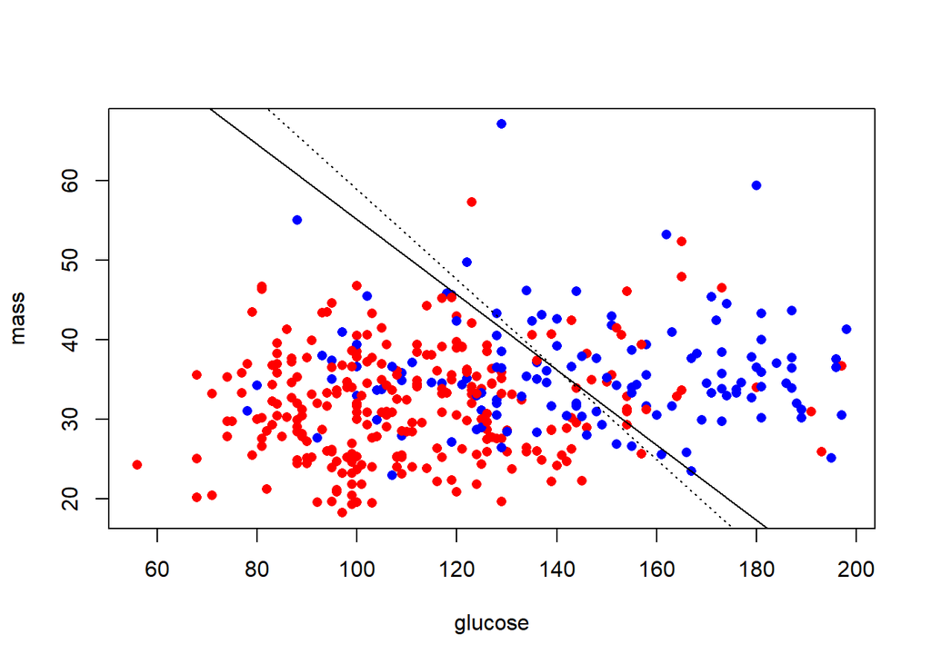

```r
logit.model2 <- glm(diabetes ~ glucose + mass, data = complete.pimas, family = binomial(link = "logit"))

logit.coefs <- coefficients(logit.model2)
logit.slope <- -logit.coefs["glucose"]/logit.coefs["mass"]
logit.intercept <- -logit.coefs["(Intercept)"]/logit.coefs["mass"]

# Using the same parameter search as earlier
svm.model2 <- train(diabetes ~ glucose + mass, data = pimatrain, method = "svmLinearWeights", scale = FALSE,
                   trControl = trainControl(method = "repeatedcv", repeats = 5))
svm.coefs.linear <- coef(svm.model2$finalModel)
svm.linear.slope <- -svm.coefs.linear["glucose"]/svm.coefs.linear["mass"]
svm.linear.intercept <- -svm.coefs.linear["(Intercept)"]/svm.coefs.linear["mass"]
cols <- ifelse(complete.pimas$diabetes == "pos", "blue", "red")
plot(mass ~ glucose, data = complete.pimas, col = cols, pch = 16)
abline(logit.intercept, logit.slope, lty = "dotted")
abline(svm.linear.intercept, svm.linear.slope)
```

## 4.2 Nonlinear decision boundaries

Generate the regions for the `kNN` method and support vector machines using a radial kernel and comment on the differences between the generated boundaries.

**Solution**

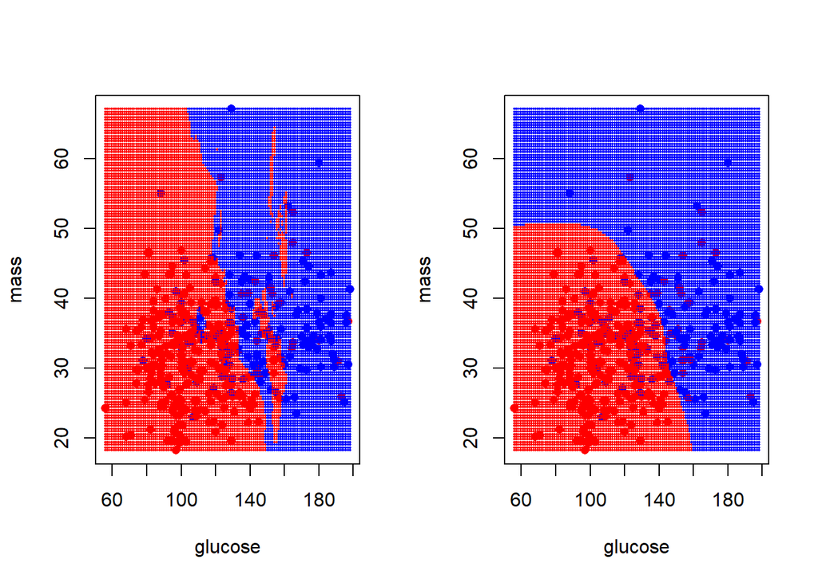

```r
viz.knn.model <- train(diabetes ~ glucose + mass, data = pimatrain, method = "knn",
                       prob = TRUE,
                       trControl = trainControl(method = "repeatedcv", repeats = 5))
# mapping decision boundary
relevant.dat <- complete.pimas %>% dplyr::select(glucose, mass)
grids <- lapply(relevant.dat, function(x) seq(from = min(x), to = max(x), length.out = 128))
viz.dat <- expand.grid(grids)
knn.predictions <- predict(viz.knn.model, viz.dat)
svm.radial.model <- train(diabetes ~ mass + glucose, data = pimatrain, method = "svmRadialWeights",
                   trControl = trainControl(method = "repeatedcv", repeats = 5))
svm.predictions <- predict(svm.radial.model, viz.dat)
par(mfrow = c(1, 2))
plot(mass ~ glucose, data = complete.pimas, col = cols, pch = 16)
points(viz.dat, col = ifelse(knn.predictions == "neg", "red", "blue"), cex = 0.3, pch = 16)
plot(mass ~ glucose, data = complete.pimas, col = cols, pch = 16)
points(viz.dat, col = ifelse(svm.predictions == "neg", "red", "blue"), cex = 0.3, pch = 16)
```

Both genreated decision regions are nonlinear and nonparametric. However, the `kNN` fits are much more volatile since they are more readily impacted by lone points in this case. The radial kernel can adapt nonlinearly but also retains smoothness.